# Initial Analysis

Vivek Katial

27/05/2020

## Introduction

This analysis looks into a building a model to for understanding $\mathbb{P}(\text{success})$.

We first need to get the data from `mlflow`. This analysis goes into detail on the steps required to go from loading the data to building various models. We also conduct an EDA on the instance features.

## Set up Environment

- Below is the code to load all the packages and files to set up the environment.
- We also load the “enriched” data into our environment.

```r
# Import libraries
library(here)
library(igraph)
library(cowplot)
library(grid)
library(gridExtra)
library(rpart)
library(randomForest)
library(modelr)
library(tidyverse)
library(GGally)
library(RColorBrewer)
library(corrplot)

# Set knitr options
knitr::opts_chunk$set(echo = TRUE, warning = F, message = F, error = F, fig.align = 'center', fig.width = 10)

# Source in relavent scripts
source(here("utils/mlflow-utils.R"))
source(here("utils/plotting-utils.R"))
source(here("analysis/enrichments/variable-clause-graph.R"))
source(here("analysis/enrichments/variable-graph.R"))

# Load in enriched data
d_enriched <- read_rds(here("data/d_enriched.rds"))
d_runs <- get_mlflow_data(here("data/d_runs.csv"))
```

```
## 2020-08-20 14:48:55 INFO::Data last updated 2020-08-19 12:18:51
```

Our enriched dataset has a naming convention based on the prefix in each column, we describe the numeric columns below:

- `metrics_<METRIC>`: With the exception of `metrics_clause_var_ratio` (Clause to variable ratio), these are metrics which are calculated **during** our simulation and cannot be calculated prior to evolving our system.
- `params_<PARAMETER>`: With the exception of `params_instance_index` (Index for randomly generated problem), these are input parameters to our system’s evolution
- `f_p_size_<FEATURE>`: These are features related to the *problem size* of our instance.
- `f_vcg_<FEATURE>`: These are features related to the *variable clause graph* of our instance.
- `f_vg_<FEATURE>`: These are features related to the *variable graph* of our instance

### Variable Clause Graph

Variable-Clause Graph (VCG) is a bipartite graph with a node for each variable, a node for each clause, and an edge between them whenever a variable occurs in a clause.

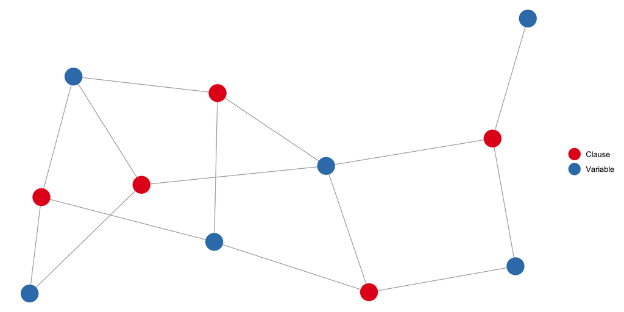

```r
example_d_clauses = list(
  k_1 = c(1L, 3L, 4L),
  k_2 = c(1L, 5L, 6L),
  k_3 = c(1L, 4L, 6L),
  k_4 = c(2L, 5L, 6L),
  k_5 = c(1L, 2L, 5L)
  )

colrs = c("tomato", "gold")
example_qubits = 6
example_var_clause_graph = make_variable_clause_graph(d_clauses = example_d_clauses, example_qubits, ret.all = T)


ggnet2(example_var_clause_graph$vcg, color = "color", palette = "Set2") +
    scale_color_brewer(
      "",
      palette = "Set1",
      labels = c("tomato" = "Variable", "gold" = "Clause"),
      guide = guide_legend(override.aes = list(size = 6))
    )
```

### Variable Graph

Variable Graph (VG) has a node for each variable and an edge between variables that occur together in at least one clause.

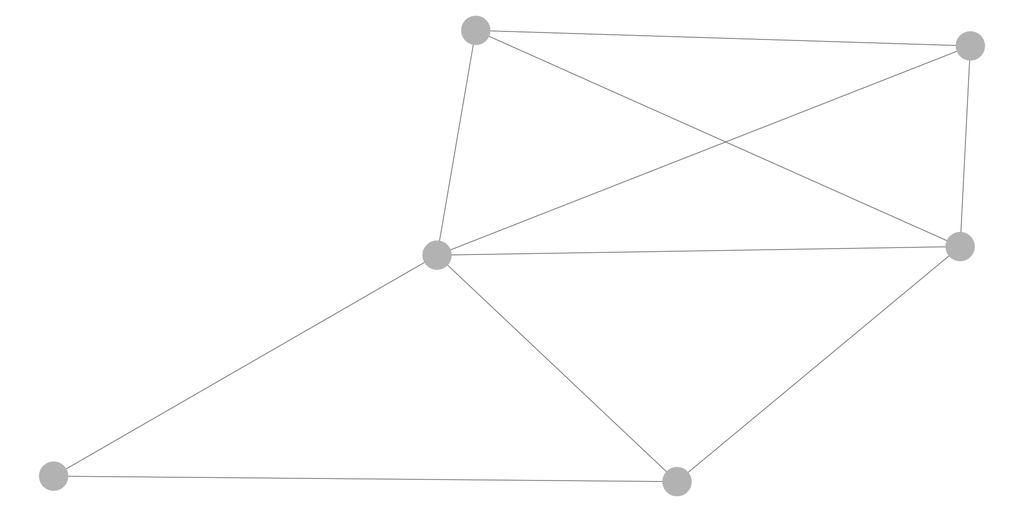

```r
example_d_clauses = list(
  k_1 = c(1L, 3L, 4L),
  k_2 = c(1L, 5L, 6L),
  k_3 = c(1L, 4L, 6L),
  k_4 = c(2L, 5L, 6L),
  k_5 = c(1L, 2L, 5L)
)

example_qubits = 6

d_clauses = example_d_clauses
n_qubits = example_qubits

var_graph = make_variable_graph(example_d_clauses, example_qubits)
ggnet2(var_graph)
```

## Normalise Data

```r
min_runs <- 10

# Find run configs with more than n=min_runs
d_configs <- d_enriched %>%
  select_if(is.numeric) %>%
  select(starts_with("params")) %>%
  count(params_n_qubits, params_time_t, params_t_step) %>%
  arrange(n) %>%
  filter(n >= min_runs) %>%
  mutate(load = T)

d_sampled <- d_enriched %>%
  left_join(d_configs, by = c("params_n_qubits", "params_time_t", "params_t_step")) %>%
  filter(load == T) %>%
  group_by(params_n_qubits, params_time_t, params_t_step) %>%
  sample_n(min_runs) %>%
  select(-experiment_id, -n) %>%
  ungroup()
```

# Experiments Run

Before we start building a model it’s useful to have a look at what experiments have ran so far.

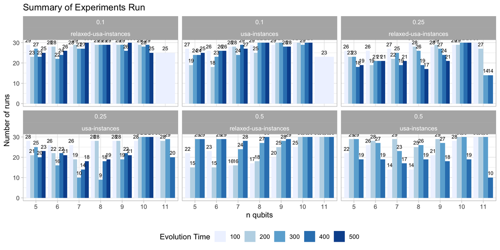

```r
d_runs %>%
  count(params_n_qubits, params_t_step,params_instance_type, params_time_t) %>%
  arrange(n) %>%
  ggplot(aes(x = as.factor(params_n_qubits), y = n, fill = as.factor(params_time_t))) +
  geom_col(aes(fill = as.factor(params_time_t)), position = position_dodge(width = 0.9)) +
  geom_text(aes(label = n), position = position_dodge(width = 0.9), vjust = -0.7, size = 2.6) +
  scale_fill_brewer(palette = "Blues", name = "Evolution Time") +
  theme_light() +
  facet_wrap(c("params_t_step", "params_instance_type")) +
  theme(
    legend.position = "bottom"
  ) +
  labs(
    x = "n qubits",
    y = "Number of runs",
    title = "Summary of Experiments Run "
  )
```

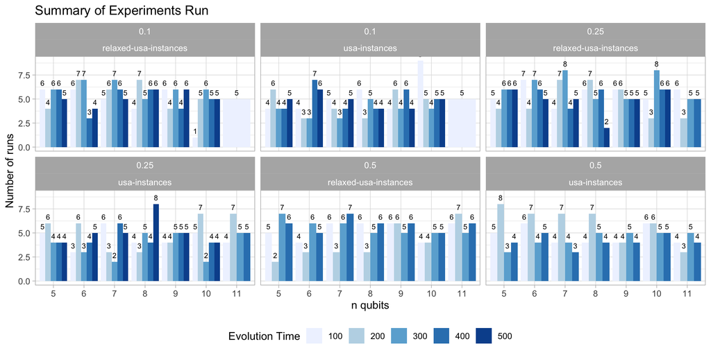

```r
d_sampled %>%
  count(params_n_qubits, params_t_step, params_time_t,params_instance_type) %>%
  arrange(n) %>%
  ggplot(aes(x = as.factor(params_n_qubits), y = n, fill = as.factor(params_time_t))) +
  geom_col(aes(fill = as.factor(params_time_t)), position = position_dodge(width = 0.9)) +
  geom_text(aes(label = n), position = position_dodge(width = 0.9), vjust = -0.7, size = 2.6) +
  scale_fill_brewer(palette = "Blues", name = "Evolution Time") +
  theme_light() +
  facet_wrap(c("params_t_step", "params_instance_type")) +
  theme(
    legend.position = "bottom"
  ) +
  labs(
    x = "n qubits",
    y = "Number of runs",
    title = "Summary of Experiments Run "
  )
```

## Energy and Entanglement vs Number of Qubits

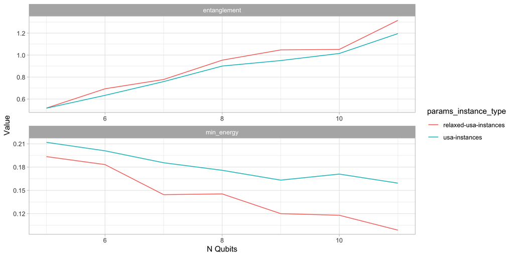

```r
d_sampled %>%
  group_by(params_n_qubits, params_instance_type) %>%
  summarise(
    entanglement = mean(metrics_max_shannon_entropy,na.rm = T),
    min_energy = mean(metrics_min_energy_gap, na.rm = T)
  ) %>%
  gather(metric, value, -params_n_qubits, -params_instance_type) %>%
  ggplot(aes(x = params_n_qubits, y = value, col = params_instance_type)) +
  geom_line() +
  facet_wrap(~metric, scales = "free", ncol = 1) +
  theme_light() +
  labs(
    x = "N Qubits",
    y = "Value"
  )
```

## Shannon Entropy vs Clause-to-variable ratio (by qubits)

We notice that for a smaller number of qubits we have almost no variance in the number of instances generated (this is noticed by clause-to-variable-ratio). We also see that our maximum shannon entropy *decreases* as we run our evolution longer.

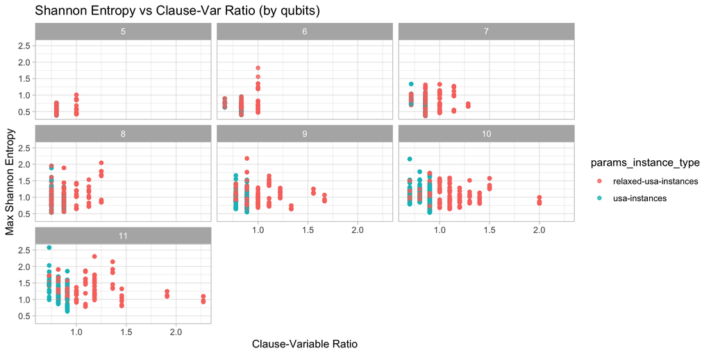

```r
d_enriched %>%
  select(
    metrics_clause_var_ratio,
    metrics_min_energy_gap,
    metrics_max_shannon_entropy,
    params_n_qubits,
    params_time_t,
    params_instance_type
  ) %>%
  mutate(
    params_n_qubits = as.factor(params_n_qubits)
    ) %>%
  ggplot(aes(x = metrics_clause_var_ratio, y = metrics_max_shannon_entropy, col = params_instance_type)) +
  geom_point(alpha = 0.8) +
  facet_wrap(~params_n_qubits) +
  theme_light() +
  labs(
    x = "Clause-Variable Ratio",
    y = "Max Shannon Entropy",
    title = "Shannon Entropy vs Clause-Var Ratio (by qubits)"
  )
```

## $\mathbb{P}(\text{success})$ over T

One of the key metrics we’re interested in is $\mathbb{P}(\text{success})$. As we see probability of sucess increasing as the evolution run time of the algorithm continues, we observe a higher $\mathbb{P}(\text{success})$. We also observe a higher variance.

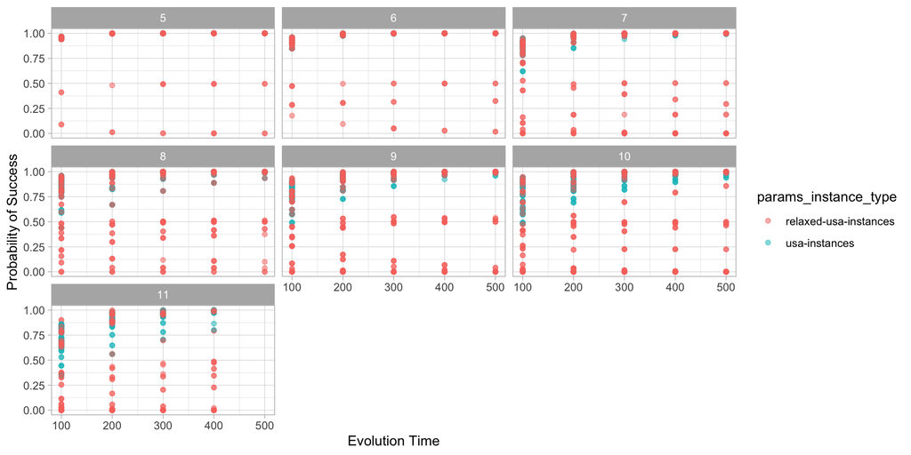

```r
d_enriched %>%
  select(metrics_p_success, params_n_qubits, params_time_t, params_t_step, params_instance_type) %>%
  mutate(
    params_time_t = as.numeric(params_time_t),
    params_t_step = as.factor(params_t_step)
  ) %>%
  ggplot(aes(x = params_time_t, y = metrics_p_success, col = params_instance_type)) +
  geom_point(alpha = 0.5) +
  facet_wrap(~as.numeric(params_n_qubits)) +
  labs(
    y = "Probability of Success",
    x = "Evolution Time"
  ) +
  theme_light()
```

## Shannon Entropy vs $\mathbb{P}(\text{success})$ (by T)

Here we clearly observe that a lower shannon entropy corresponds to a higher probability of success, but this may also be confounded due to the algorithm run time, $T$.

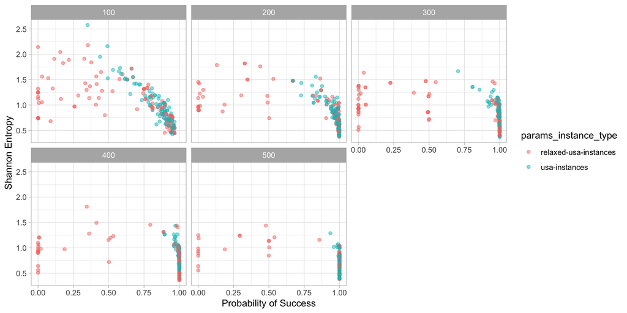

```r
d_sampled %>%
  select(metrics_p_success, metrics_max_shannon_entropy, params_time_t, params_instance_type) %>%
  ggplot(aes(x = metrics_p_success, y = metrics_max_shannon_entropy, col = params_instance_type)) +
  geom_point(alpha = 0.5) +
  labs(
    x = "Probability of Success",
    y = "Shannon Entropy"
  ) +
  facet_wrap(~params_time_t) +
  theme_light()
```

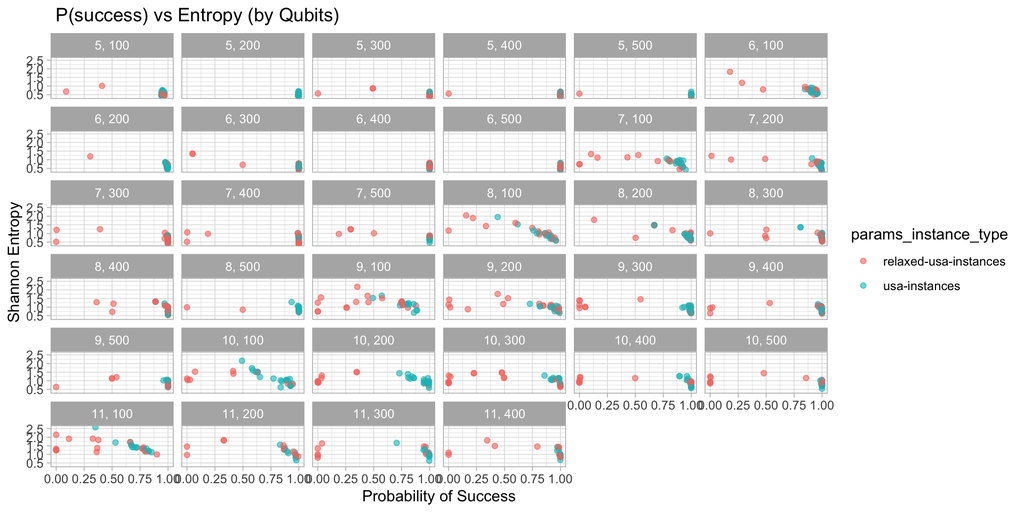

```r
d_sampled %>%
  select(
    metrics_p_success,
    metrics_max_shannon_entropy,
    params_time_t,
    params_n_qubits,
    params_instance_type
    ) %>%
  ggplot(aes(x = metrics_p_success, y = metrics_max_shannon_entropy, col = params_instance_type)) +
  geom_point(alpha = 0.6) +
  facet_wrap(c("params_n_qubits", "params_time_t"),  labeller = label_wrap_gen(multi_line=FALSE)) +
  labs(
    x = "Probability of Success",
    y = "Shannon Entropy",
    title = " P(success) vs Entropy (by Qubits)"
  ) +
  theme_light()
```

## Min Energy Gap vs $\mathbb{P}(\text{success})$

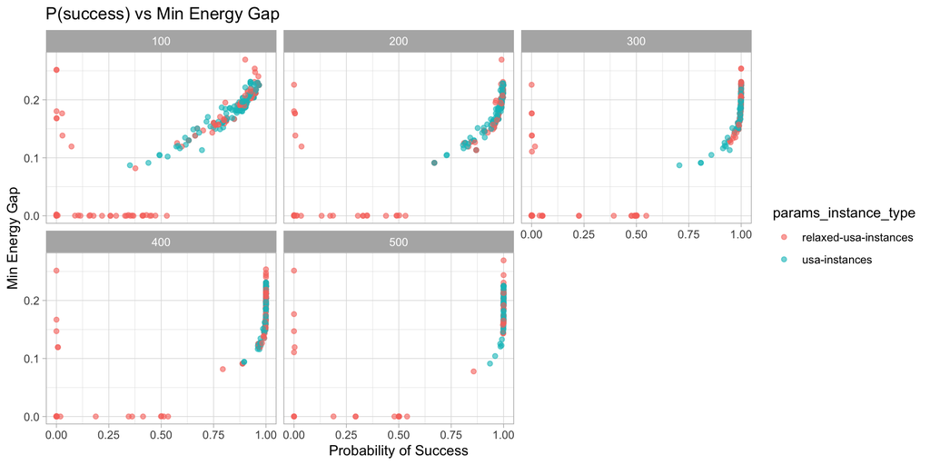

```r
d_sampled %>%
  select(metrics_p_success, metrics_min_energy_gap, params_time_t, params_instance_type) %>%
  ggplot(aes(x = metrics_p_success, y = metrics_min_energy_gap, col = params_instance_type)) +
  geom_point(alpha = 0.6) +
  theme_light() +
  facet_wrap(~params_time_t) +
  labs(
    x = "Probability of Success",
    y = "Min Energy Gap",
    title =  "P(success) vs Min Energy Gap"
  )
```

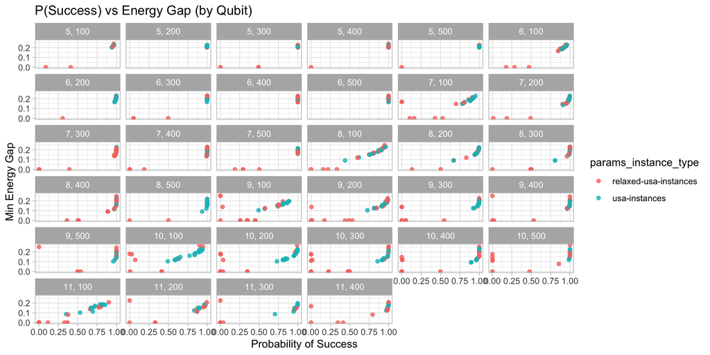

```r
d_sampled %>%
  select(metrics_p_success, metrics_min_energy_gap, params_time_t, params_n_qubits, params_instance_type) %>%
  ggplot(aes(x = metrics_p_success, y = metrics_min_energy_gap, col = params_instance_type)) +
  geom_point(alpha = 0.8) +
  facet_wrap(~params_n_qubits+params_time_t, labeller = label_wrap_gen(multi_line=FALSE)) +
  theme_light() +
  labs(
    x = "Probability of Success",
    y = "Min Energy Gap",
    title = "P(Success) vs Energy Gap (by Qubit)"
  )
```

## Clause to Var Ratio vs $\mathbb{P}(\text{success})$

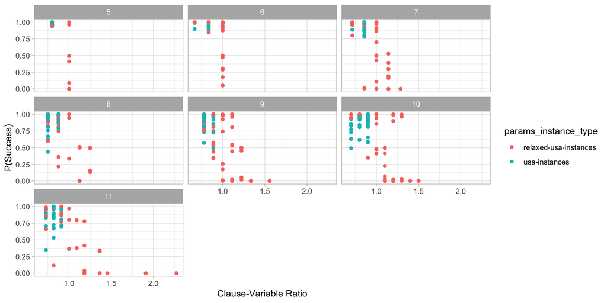

```r
d_sampled %>%
  select(
    metrics_p_success,
    metrics_clause_var_ratio,
    params_n_qubits,
    params_time_t,
    params_instance_type
    ) %>%
  ggplot(aes(x = metrics_clause_var_ratio, y = metrics_p_success, col = params_instance_type)) +
  geom_point() +
  facet_wrap(~params_n_qubits) +
  theme_light() +
  labs(
    x = "Clause-Variable Ratio",
    y = "P(Success)"
  )
```